# EVSI calculation for model development

Abdollah Safari

2025-04-18

## Introduction

This is a step-by-step vignette for EVSI calculation for model development. The methodology used in this vignette can be found from our manscript titled “Expected value of sample information calculations for risk prediction model development” available at https://arxiv.org/abs/2410.03096.

## Dataset

As a case study, we apply our findings to GUSTO-I, a clinical trial of multiple thrombolytic strategies for acute myocardial infarction (AMI, or ‘heart attack’) (GUSTO Investigators, 1993). The GUSTO trial was a four-arm randomized clinical trial that compared the efficacy of different intravenous thrombolytic regimens for AMI. This dataset has been widely used for methodological research in predictive analytics.

We use these data to build a prediction model for predicting 30-day mortality for AMI. We used sex, age, diabetes (yes or no), milocc (which part of the heart muscle is affected by the blocked artery and coded as 3=anterior, 4=inferior, 5=other, and 6=no MI), previous MI, hypertension, smoking, killip class, and treatment as covariates in the model. Here is the top a few rows of this dataset:

```r
data("gusto")

gusto %>%
  select(day30, sex, age, dia, miloc, pmi, hyp, smk, Killip, tx) %>%
  head
```

```
##   day30  sex    age dia    miloc pmi hyp     smk Killip     tx
## 1     0 male 19.027   0 Anterior  no   0   never      I     SK
## 2     0 male 19.031   0 Anterior yes   0   never     II SK+tPA
## 3     0 male 20.289   0 Inferior  no   0 current      I SK+tPA
## 4     0 male 20.781   0 Inferior  no   0   never      I    tPA
## 5     0 male 20.969   0 Anterior  no   0    quit      I     SK
## 6     0 male 20.984   0 Inferior  no   0   never      I    tPA
```

We set a risk threshold of 1% as the default threshold, but will evaluate the model at the entire possible range of thresholds. Given the relatively large sample size (n=40830), the uncertainty in predictions when the model is fitted using the full sample is negligible. Indeed, a previous study reported an EVPI of 0 with the full dataset (thus, EVSI will be zero for all sample sizes). Therefore, we took, without replacement, a random sub-sample of 1000 patients from GUSTO data and treat that as our development sample (source of current information).

## Initial setup

```r
bootstrap <- function (n, Bayesian = T)
{
  if(Bayesian)
  {
    u <- c(0, sort(runif(n - 1)), 1)
    return((u[-1] - u[-length(u)]) * n)
  }
  else
  {
    u <- rmultinom(1, n, rep(1 / n, n))
    return(u[ , 1])
  }
}

winner_finder <- function(x) {
  max(x)
}


settings <- list()
settings$master_formula <-
  "y ~ sex + age + dia + miloc + pmi + htn + smk + kill + tx - 1"
settings$n_rep <- 10000 # of times repeating whole process
settings$initial_n <- 1000 # The development initial sample size
settings$future_n <- c(100, 500, 1000, 2000, 4000, 8000, 16000, 32000)

## development sample (a subsample of gusto)
set.seed(1234)
dev_rct <-
  gusto %>%
  filter(complete.cases(.),
         regl %in% c(1, 7, 9, 10, 11, 12, 14, 15)) %>% ## US region
  mutate(kill = (as.numeric(Killip) > 1) * 1) %>%
  sample_n(size = settings$initial_n, replace = F) %>%
  rename(y = day30)# %>%

dev_glm <- glm(as.formula(settings$master_formula),
               family = binomial(link = "logit"),
               data = dev_rct)
dev_rct$pi <- predict(dev_glm, type = "response")
```

## DCA

For DCA, we estimated NB of the model and the alternative default strategies (treat all and treat none) at different threshold values as well as estimated NB increments of model versus the best alternative.

```r
library(rmda)

set.seed(123)
# first use rmda with the default settings (set bootstraps = 50 here to reduce computation time).
baseline.model <- decision_curve(as.formula(settings$master_formula),
                                 data = dev_rct,
                                 study.design = "cohort",
                                 policy = "opt-in",  #default
                                 bootstraps = 50)
```

```
## Note:  The data provided is used to both fit a prediction model and to estimate the respective decision curve. This may cause bias in decision curve estimates leading to over-confidence in model performance.
```

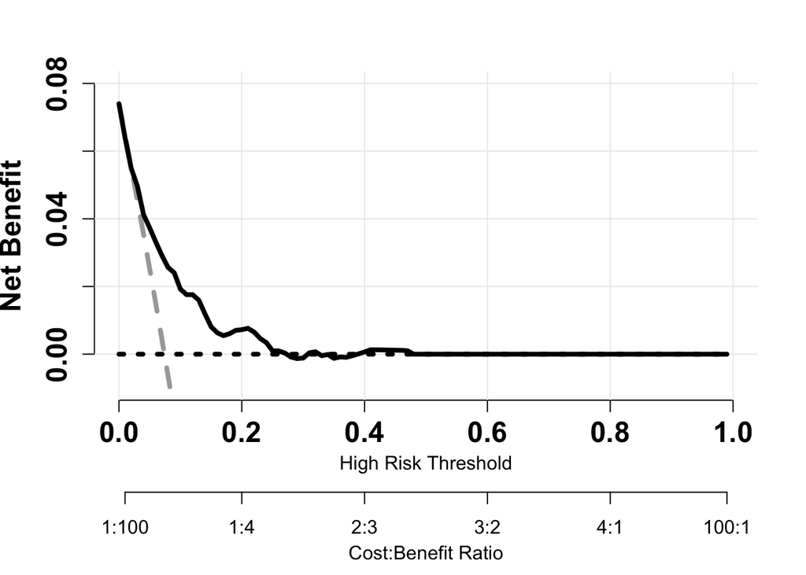

```r
#plot the curve
plot_decision_curve(baseline.model,
                    lty = c(1 : 3),
                    standardize = FALSE,
                    col = "black",
                    curve.names = "Using model",
                    legend.position = "none",
                    confidence.intervals = FALSE,
                    ylim = c(-0.01, 0.08),
                    lwd = rep(4, 3),
                    cex.lab = 1.5, cex.axis = 1.5, cex.sub = 1.5,
                    font = 2, font.lab = 2, font.sub = 2,
                    fg = "black")
```

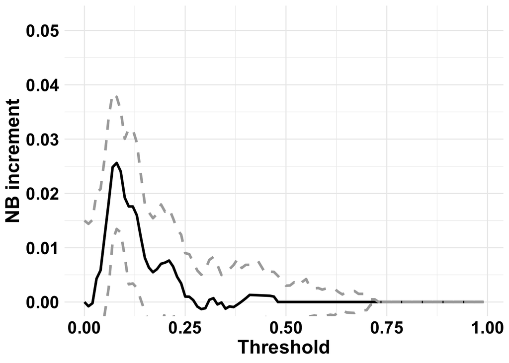

```r
baseline.model$derived.data %>%
  select(model, thresholds,
         # sNB, sNB_lower, sNB_upper,
         NB, NB_lower, NB_upper) %>%
  mutate(NB_sd = (NB_upper - NB_lower) / (2 * 1.96),
         model = ifelse(model %in% c("All", "None"),
                        model, "Model")) %>%
  arrange(thresholds) %>%
  filter(thresholds < 1) %>%
  group_by(thresholds) %>%
  mutate(#NB_max = max(NB),
         NB_alt_max = max(NB[model != "Model"]),
         NB_alt_argmax = which.max(NB[model != "Model"]),
         NB_alt_max_sd = (NB_sd[model != "Model"])[NB_alt_argmax]) %>%
  ungroup() %>%
  select(! c(NB_upper, NB_lower, NB_alt_argmax)) %>%
  filter(model == "Model") %>%
  mutate(NB_inc = NB - NB_alt_max,
         NB_inc_sd = ifelse(NB_inc == 0,
                            0,
                            # sqrt(NB_sd ^ 2 + NB_alt_max_sd ^ 2)
                            NB_sd)) %>%
  ggplot(aes(x = thresholds, y = NB_inc)) +
  geom_line(aes(color = "Model NB increment"), linewidth = 1.2,
            show.legend = TRUE, linetype = 1) +
  geom_line(aes(y = NB_inc + 1.96 * NB_sd, color = "95% CI"),
            show.legend = TRUE, linetype = 2, linewidth = 1.2) +
  geom_line(aes(y = NB_inc - 1.96 * NB_sd), linetype = 2,
            color = "darkgray", linewidth = 1.2) +
  labs(y = "NB increment", x = "Threshold", colour = "") +
  theme_minimal() +
  coord_cartesian(ylim = c(0, 0.052)) +
  scale_color_manual(breaks = c("Model NB increment", "95% CI"),
                     values = c("black", "darkgrey")) +
  theme(legend.position = "none",
        axis.text = element_text(size = 17,
                                 color = "black",
                                 face = "bold"),
        axis.title = element_text(size = 19,
                                 color = "black",
                                 face = "bold"),
        legend.text = element_text(size = 17,
                                 color = "black",
                                 face = "bold"),
        legend.title = element_text(size = 17,
                                 color = "black",
                                 face = "bold"))
```

## EVPI vs EVSI

Next, we will calculate EVPI and EVSI for model developemnt.

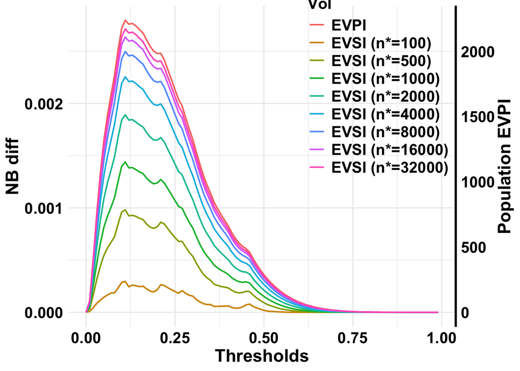

```r
lambdas <- (0 : 99) / 100
strategy_names <- c("none", "model", "all", "max")
NB_array <-
  array(0, dim = c(length(strategy_names),
                    length(lambdas)),
        dimnames = list(strategy_names,
                        lambdas))
NB_array["none", ] <- 0
strategy_names_future <- c("none", "model", "all", "max")
NB_future <- array(0,
                   dim = c(length(strategy_names_future),
                           length(lambdas),
                           length(settings$future_n)),
                   dimnames = list(strategy_names_future,
                                   lambdas,
                                   settings$future_n))
NB_future["none", , ] <- 0

for(t in 1 : settings$n_rep) {
  dev_rct_t <- dev_rct

  dev_rct_t$w <- bootstrap(settings$initial_n, Bayesian = TRUE)
  true_model_t <- glm(settings$master_formula,
                      family = binomial(link = "logit"),
                      data = dev_rct_t, weights = dev_rct_t$w)

  dev_rct_t$p <- predict(true_model_t, type = "response") # true p's

  nb_model_tmp <- sapply(lambdas, function(x) {
    mean((dev_rct_t$p - (1 - dev_rct_t$p) * x /
            (1 - x)) * (dev_rct_t$pi > x))})
  NB_array["model", ] <- NB_array["model", ] + nb_model_tmp
  nb_all_tmp <- sapply(lambdas, function(x) {
    mean((dev_rct_t$p - (1 - dev_rct_t$p) * x / (1 - x)) * (1))})
  NB_array["all", ] <- NB_array["all", ] + nb_all_tmp

  NB_array["max", ] <- NB_array["max", ] +
    sapply(lambdas, function(x) {
      mean((dev_rct_t$p - (1 - dev_rct_t$p) * x /
              (1 - x)) * (dev_rct_t$p > x))})

  future_rct_n_max <- max(settings$future_n)
  future_rct_indices <- sample(c(1 : settings$initial_n),
                               size = future_rct_n_max,
                               prob = dev_rct_t$w,
                               replace = TRUE)
  future_rct_all <- dev_rct_t[future_rct_indices , ]
  # new Y's only for future rct
  future_rct_all$y <- rbinom(n = future_rct_n_max, size = 1,
                             future_rct_all$p)

  # s = 1
  for (s in 1 : length(settings$future_n))
  {
    dev_future_rct <-
      rbind(dev_rct_t, future_rct_all[c(1 : settings$future_n[s]) , ])

    dev_future_model <- glm(settings$master_formula,
                              family = binomial(link = "logit"),
                              data = dev_future_rct)
    dev_future_rct$pi_future <- predict(dev_future_model, type = "response")
    dev_rct_t$pi_from_future <- predict(dev_future_model,
                                          newdata = dev_rct_t,
                                          type = "response")

    nb_future_model_tmp <- sapply(lambdas, function(x) {
      mean((dev_rct_t$p - (1 - dev_rct_t$p) *
              x / (1 - x)) * (dev_rct_t$pi_from_future > x))})
    NB_future["model", , as.character(settings$future_n[s])] <-
      NB_future["model", , as.character(settings$future_n[s])] +
      nb_future_model_tmp
    nb_future_all_tmp <- sapply(lambdas, function(x) {
      mean((dev_rct_t$p - (1 - dev_rct_t$p) *
              x / (1 - x)) * (1))})
    NB_future["all", , as.character(settings$future_n[s])] <-
      NB_future["all", , as.character(settings$future_n[s])] +
      nb_future_all_tmp

    NB_future["max", , as.character(settings$future_n[s])] <-
      NB_future["max", , as.character(settings$future_n[s])] +
      apply(cbind(nb_future_model_tmp, nb_future_all_tmp, 0), 1, max)

    dev_rct_t %<>%
      select(! c(pi_from_future))
  }
}

NB_array_mean <- NB_array / settings$n_rep
evpi_max <-
  apply(NB_array_mean, 2, function(x) x[4] - max(x[-c(4, 5)]))


NB_future_mean <- NB_future / settings$n_rep
evsi <- matrix(NA, nrow = length(lambdas), ncol = length(settings$future_n))
evsi_orgSample <-
  apply(NB_array_mean, 2, function(x) winner_finder(x[-c(4 : 5)]))
for (i in c(1 : length(settings$future_n))) {
  NB_future_mean_tmp <- NB_future_mean[ , , as.character(settings$future_n[i])]
  evsi_futSample_temp <- apply(NB_future_mean_tmp, 2, function(x) winner_finder(x[-4]))
  evsi[ , i] <- evsi_futSample_temp - evsi_orgSample
}

tibble(Thresholds = lambdas,
       evpi = evpi_max,
       evsi_1 = evsi[ , 1],
       evsi_2 = evsi[ , 2],
       evsi_3 = evsi[ , 3],
       evsi_4 = evsi[ , 4],
       evsi_5 = evsi[ , 5],
       evsi_6 = evsi[ , 6],
       evsi_7 = evsi[ , 7],
       evsi_8 = evsi[ , 8]) %>%
  pivot_longer(cols = c(evpi, evsi_1 : evsi_8),
               names_to = "VoI",
               values_to = "NB diff") %>%
  mutate(VoI = factor(VoI,
                      levels = c("evpi",
                                 paste0("evsi_", c(1 : 8))),
                      labels = c("EVPI",
                                 paste0("EVSI (n*=", settings$future_n, ")")))) %>%
  ggplot(aes(x = Thresholds, y = `NB diff`,
             group = VoI, color = VoI)) +
  geom_line(size = 0.7) +
  lims(y = c(0, 0.003)) +
  scale_y_continuous(sec.axis = sec_axis(~ 800000 * .,
                                         name = "Population EVPI")) +
  theme_minimal() +
  theme(legend.position = c(0.8, 0.75),
        axis.text = element_text(size = 15,
                                 color = "black",
                                 face = "bold"),
        axis.title = element_text(size = 17,
                                 color = "black",
                                 face = "bold"),
        axis.line.y.right = element_line(color = "black",
                                         linetype = 1,
                                         linewidth = 1),
        axis.title.y.right = element_text(angle = 90),
        legend.text = element_text(size = 15,
                                 color = "black",
                                 face = "bold"),
        legend.title = element_text(size = 15,
                                 color = "black",
                                 face = "bold"))
```

## EVSI curve

Next, we Compute EVSI (left Y-axis) and its scaling at population (right Y-axis) with different future sample sizes (red curve) at threshold value of z= 0.01 compared to its corresponding computed EVPI (black curve). Dotted/dashed vertical curves are the estimated sample sizes based on the three criteria of Riley and others (2024).

```r
dev_rct_lp <- predict(dev_glm, type = "link")
library(pROC)
dev_roc <- roc(dev_rct$y ~ dev_rct$pi, print.auc = TRUE)
library(pmsampsize)
Riley_def_ss <-
  pmsampsize(type = "b",
             cstatistic = dev_roc$auc,
             parameters = 13,
             prevalence = mean(dev_rct$y),
             shrinkage = 0.9)

(thresh_z <- which(names(evpi_max) == "0.01"))
```

```
## [1] 2
```

```r
lambdas[thresh_z]
```

```
## [1] 0.01
```

```r
evpi_max[thresh_z]
```

```
##         0.01
## 0.0001112755
```

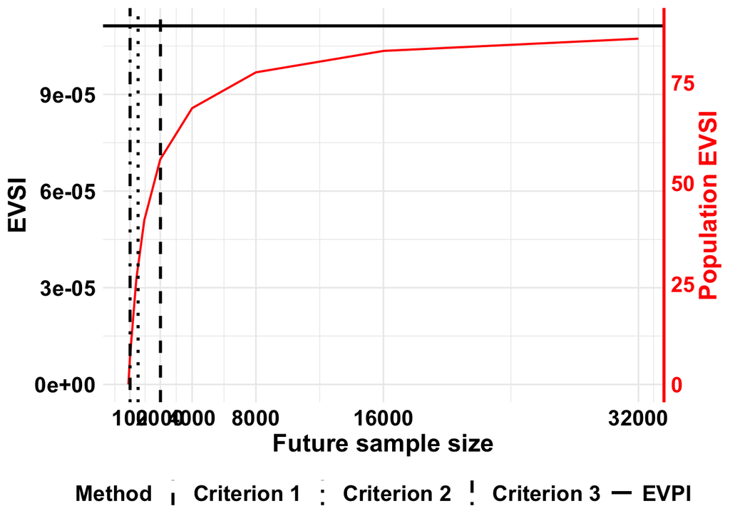

```r
tibble(Sample_size = c(0, settings$future_n),
       evsi = c(0, evsi[thresh_z , ])) %>%
  ggplot(aes(x = Sample_size, y = evsi)) +
  geom_line(size = 0.7, color = "red") +
  geom_hline(aes(yintercept = evpi_max[thresh_z],
                 linetype = "EVPI"),
             linewidth = 1) +
  geom_vline(aes(xintercept = Riley_def_ss$results_table[1, 1],
                 linetype = "Criterion 1"),
             linewidth = 1) +
  geom_vline(aes(xintercept = Riley_def_ss$results_table[2, 1],
                 linetype = "Criterion 2"),
             linewidth = 1) +
  geom_vline(aes(xintercept = Riley_def_ss$results_table[3, 1],
                 linetype = "Criterion 3"),
             linewidth = 1) +
  scale_linetype_manual(name = "Method",
                        values = c(EVPI = 1,
                                   # `Riley et al. (2018) - Criterion 1` = 2,
                                   `Criterion 1` = 2,
                                   `Criterion 2` = 3,
                                   `Criterion 3` = 4)) +
  scale_x_continuous(breaks = settings$future_n[-c(2, 3)]) +
  scale_y_continuous(sec.axis = sec_axis(~800000 * .,
                                         name = "Population EVSI")) +
  theme_minimal() +
  labs(x = "Future sample size", y = "EVSI") +
  theme(legend.position = "bottom",
        axis.text = element_text(size = 15,
                                 color = "black",
                                 face = "bold"),
        axis.title = element_text(size = 17,
                                 color = "black",
                                 face = "bold"),
        axis.line.y.right = element_line(color = "red",
                                         linetype = 1,
                                         linewidth = 1),
        axis.title.y.right = element_text(angle = 90,
                                          color = "red"),
        axis.text.y.right = element_text(color = "red"),
        legend.text = element_text(size = 15,
                                 color = "black",
                                 face = "bold"),
        legend.title = element_text(size = 15,
                                 color = "black",
                                 face = "bold"),
        axis.minor.ticks.x.bottom = element_blank())
```

As anticipated, EVSI increases with larger future sample sizes, eventually asymptoting to the EVPI. The expected NB gain (left Y-axis) exhibits a steep increase at smaller sample sizes, followed by a plateau as n∗ grows, reflecting a “diminishing return” pattern. Similar to the EVPI plot in Panel A, we scale the EVSI to the population level, with the corresponding values displayed on the right Y-axis of the figure. At 0.01 threshold, a future study of size n∗= 1,000 has a per-decision EVSI value of 0.000049, corresponding to population value of 39 in true positive cases gained (or 3,881 in false positive cases averted), while a future study of size n= 16,000 has a per-decision EVSI value of 0.00010, corresponding to population value of 82 in true positive cases gained (or 8,141 in false positive cases averted).